# IsyE 603 HW 5

## Problem 1

1. MA(3) - The ACF has three spikes and the PACF dies out in an exponential manner.
2. ARIMA(2,0,1)
3. ARIMA(1,1,1)

d)AR(2) - This is because the ACF plot shows a sinusodial pattern, while the PACF shows just two significant spikes

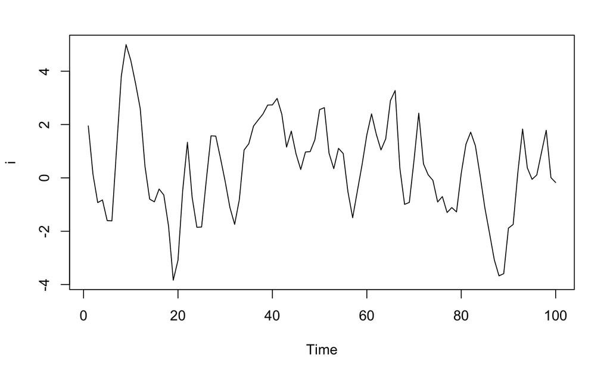

```r
#Problem 2(c)
#Using arima.sim function in R to simulate the three models and plot the simulated series. Make the length of the time series be 100.
library(graphics)
#first model
i<-arima.sim(model = list(order = c(1,0,1), ar = 0.7, ma = 0.6), n = 100)
plot(i)
```

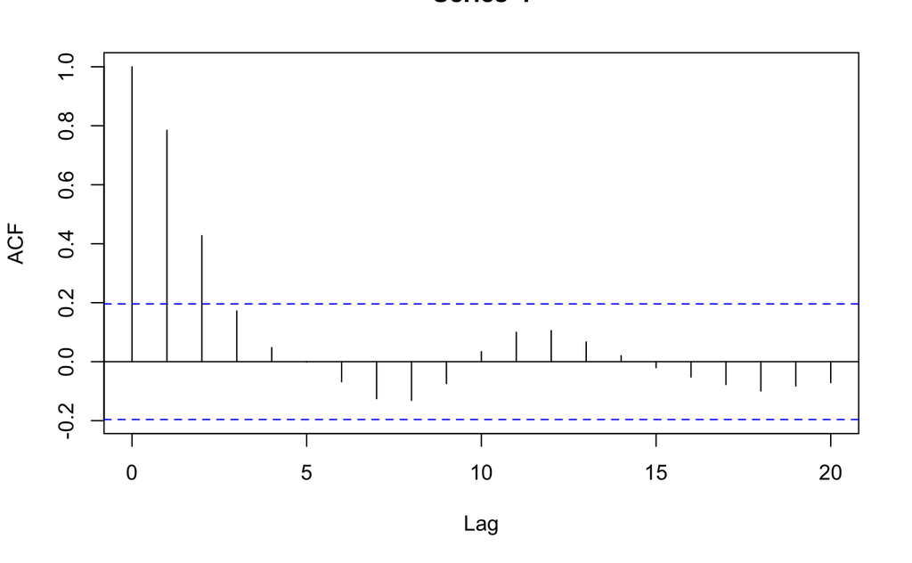

```r
acf(i)
```

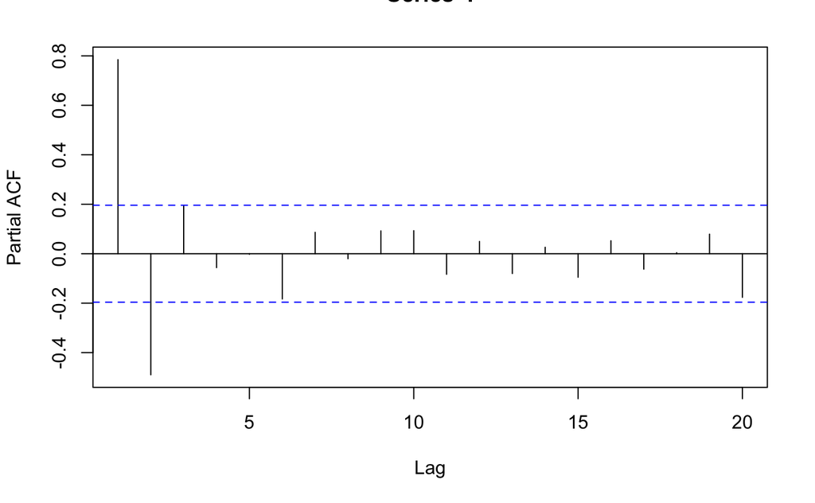

```r
pacf(i)
```

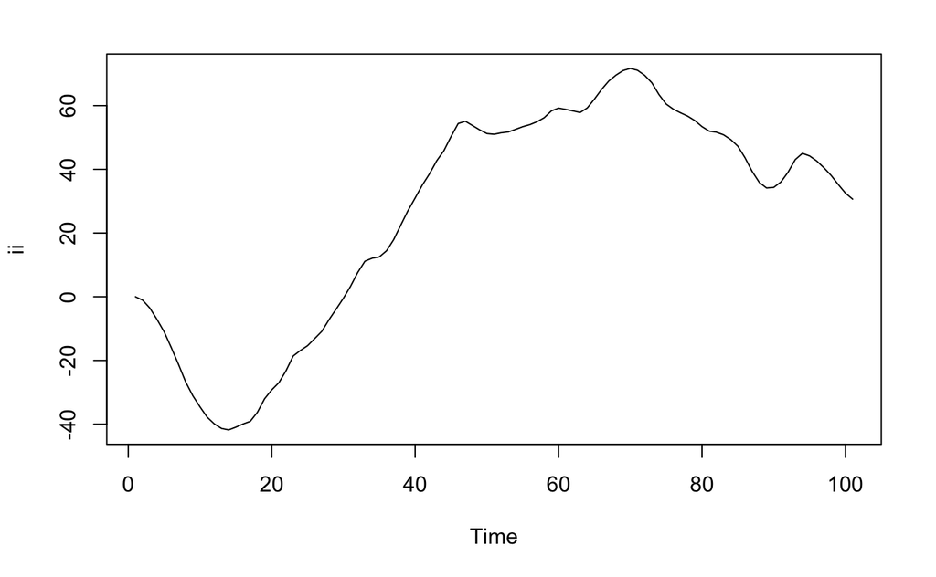

```r
#second model
ii<-arima.sim(model = list(order = c(1,1, 1), ar = 0.7, ma = 0.6), n = 100)
plot(ii)
```

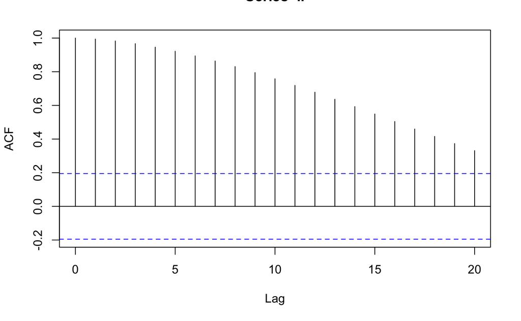

```r
acf(ii)
```

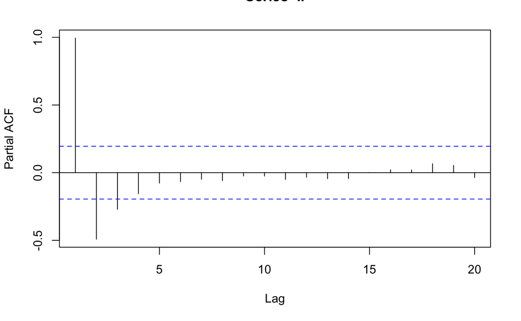

```r
pacf(ii)
```

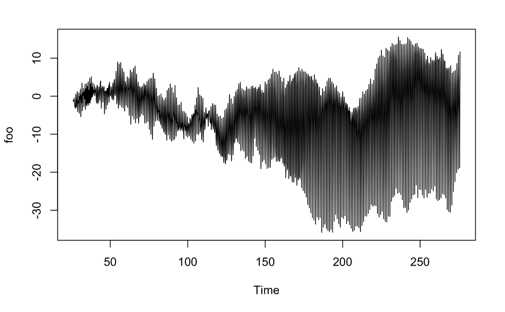

```r
#third model
 library(forecast)
    model_1 <- Arima(ts(rnorm(100),freq=4), order=c(1,0,1), seasonal=c(0,1,0),
                 fixed=c(phi=0.7, theta=-0.6))
    foo <- simulate(model_1, nsim=1000)
    plot(foo)
```

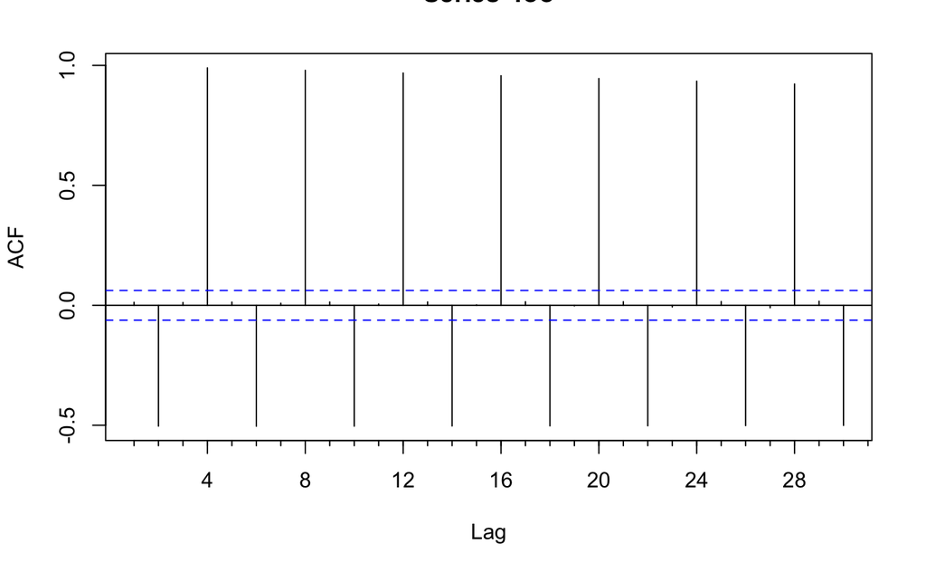

```r
    Acf(foo)
```

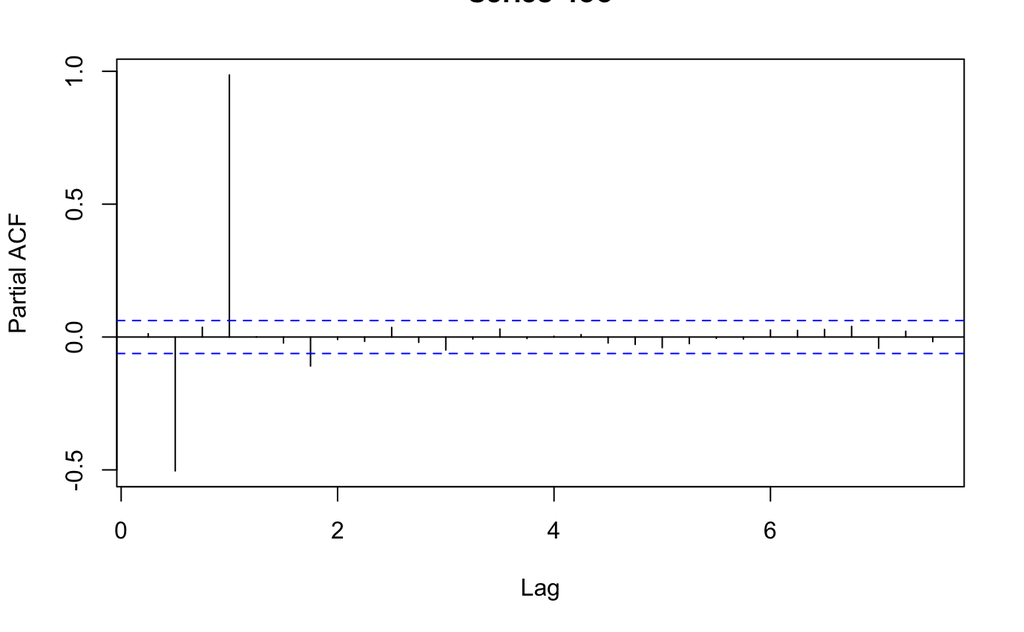

```r
    pacf(foo)
```

```r
#Problem 3a
#Getting the ARIMA Model
library(fpp3)
fit <- aus_airpassengers %>%
  model(ARIMA(Passengers))
report(fit)
```

```
Series: Passengers
Model: ARIMA(0,2,1)

Coefficients:
          ma1
      -0.8963
s.e.   0.0594

sigma^2 estimated as 4.308:  log likelihood=-97.02
AIC=198.04   AICc=198.32   BIC=201.65
```

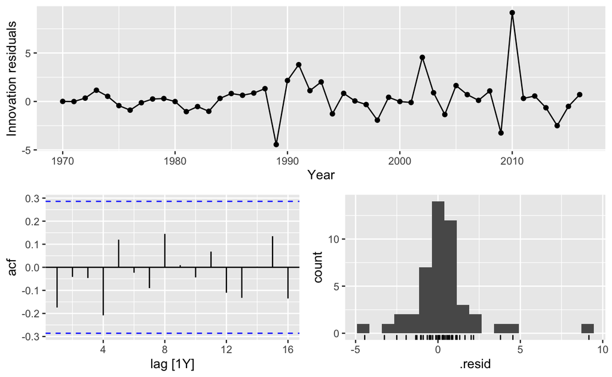

```r
#Plotting the ACF and PACF of residuals
fit %>% gg_tsresiduals()
```

```
Plot variable not specified, automatically selected `y = .resid`
```

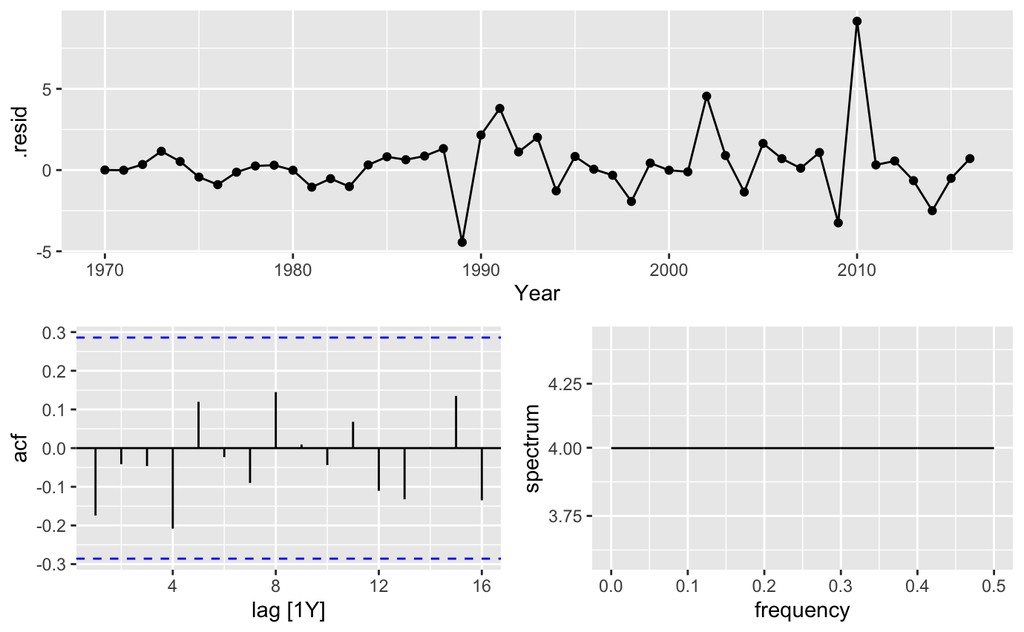

```r
#This code is supposed to plot the PACF alongside the ACF but it comes in as just a straight line
gg_tsdisplay(residuals(fit))
```

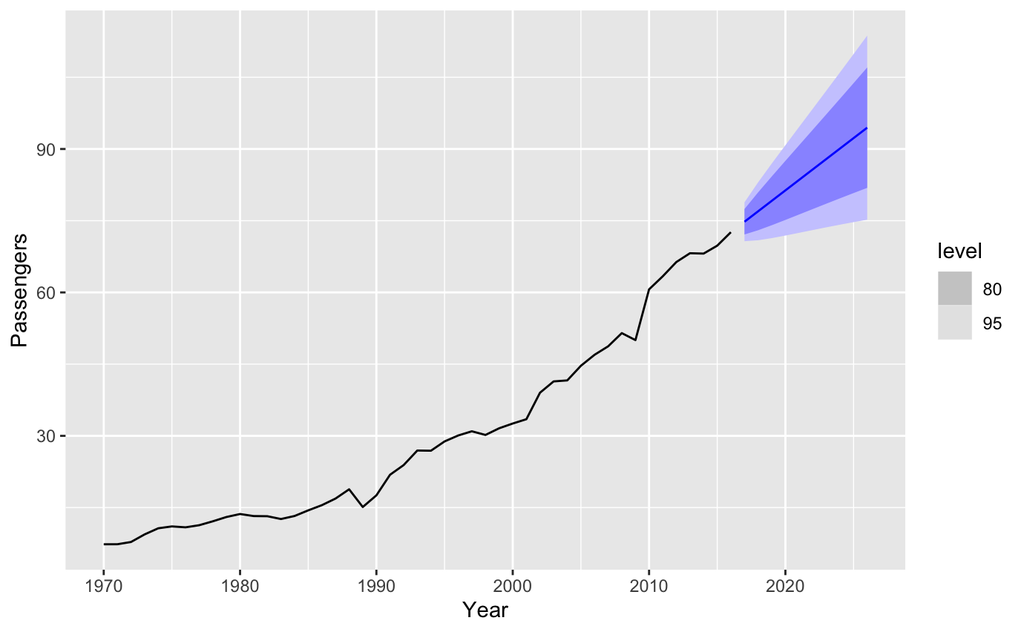

```r
#Plotting the forecasts for the next 10 periods
fit %>% forecast(h=10) %>%
  autoplot(aus_airpassengers)
```

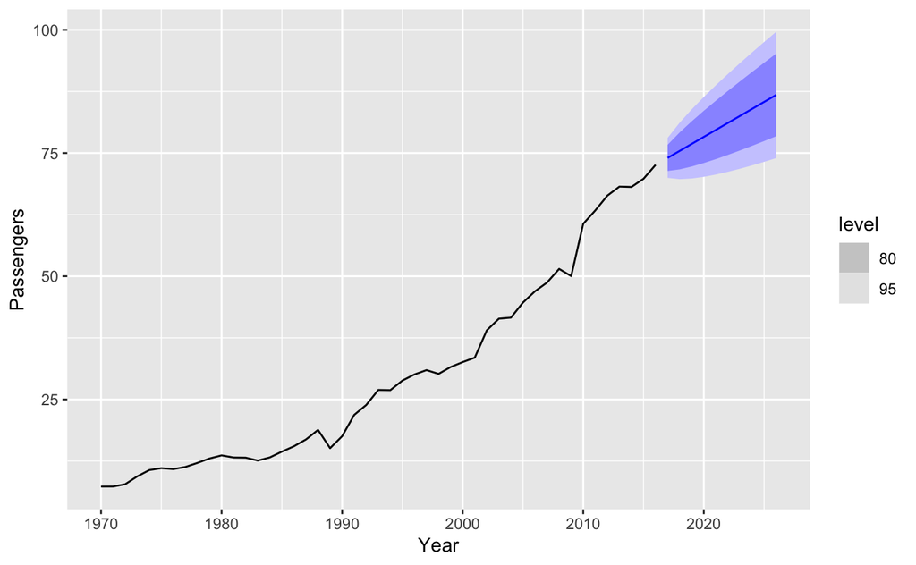

```r
#Problem 3c
#Plotting theforecast of a model from (0,1,0) with drift
fit1 <- aus_airpassengers %>%
model(arima = ARIMA(Passengers ~ pdq(0, 1, 0)))

#plot forecast for next 10 periods
fit1 %>% forecast(h=10) %>%
  autoplot(aus_airpassengers)
```

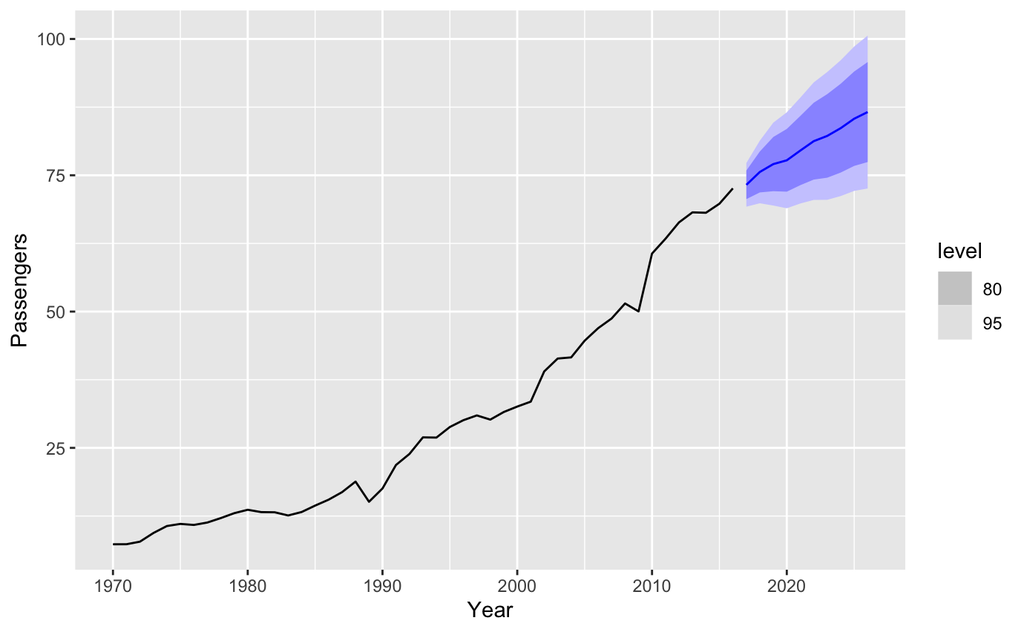

```r
#Problem 3d
#Plotting theforecast of a model from (2,1,2) with drift
fit2 <- aus_airpassengers %>%
# 1 is the drift
model(arima = ARIMA(Passengers ~ 1 + pdq(2,1,2)))

#plot forecast for next 10 periods
fit2 %>% forecast(h=10) %>%
  autoplot(aus_airpassengers)
```

## Problem 3a

The model is ARIMA(0,2,1)

## Problem 3c

The model ARIMA (0,1,0) with the drift has an upward trend like the model in part a . However, the trend is not as rapid as that of part a.

## Problem 3d

The model ARIMA (2,1,2) with the drift has an upward trend like the model in part a . However, the trend is not as rapid as that of part a.

```r
#Problem 4a
library(zoo)
library(forecast)
SouvenirSales.data <- read.csv(file ='SouvenirSales.csv', header = TRUE)
#creating the data in a time series format spanning from  Jan 1995 to  Dec. 2001 using a freq of 12
Sales.ts <- ts(SouvenirSales.data$Sales, start = c(1995,1), end = c(2001, 12), freq = 12)
fixed.nValid <- 12
# since we have a fixed valid the rest will be training.
fixed.nTrain <- length(Sales.ts) - fixed.nValid
#training period
train.ts <- window(Sales.ts, start = c(1995, 1), end = c(1995, fixed.nTrain))
#validation period
valid.ts <- window(Sales.ts, start = c(1995, fixed.nTrain + 1), end = c(1995, fixed.nTrain + fixed.nValid))

##Running the regression for modelA- used only training period only
Model_A <- tslm(train.ts ~ trend + season)
summary(Model_A)
```

```
Call:
tslm(formula = train.ts ~ trend + season)

Residuals:
   Min     1Q Median     3Q    Max
-12592  -2359   -411   1940  33651

Coefficients:
            Estimate Std. Error t value Pr(>|t|)
(Intercept) -3065.55    2640.26  -1.161  0.25029
trend         245.36      34.08   7.199 1.24e-09 ***
season2      1119.38    3422.06   0.327  0.74474
season3      4408.84    3422.56   1.288  0.20272
season4      1462.57    3423.41   0.427  0.67077
season5      1446.19    3424.60   0.422  0.67434
season6      1867.98    3426.13   0.545  0.58766
season7      2988.56    3427.99   0.872  0.38684
season8      3227.58    3430.19   0.941  0.35058
season9      3955.56    3432.73   1.152  0.25384
season10     4821.66    3435.61   1.403  0.16573
season11    11524.64    3438.82   3.351  0.00141 **
season12    32469.55    3442.36   9.432 2.19e-13 ***
---
Signif. codes:  0 ‘***’ 0.001 ‘**’ 0.01 ‘*’ 0.05 ‘.’ 0.1 ‘ ’ 1

Residual standard error: 5927 on 59 degrees of freedom
Multiple R-squared:  0.7903,    Adjusted R-squared:  0.7476
F-statistic: 18.53 on 12 and 59 DF,  p-value: 9.435e-16
```

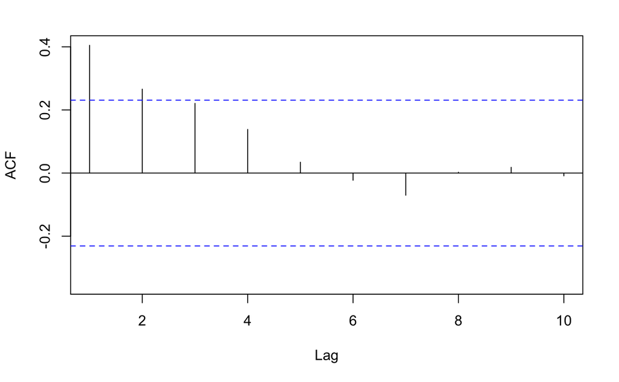

```r
#Problem 4b
#Plot ACF and PACF plot until lag 10 for residuals model in part (a)
Acf(Model_A$residuals, lag.max = 10, main = "")
```

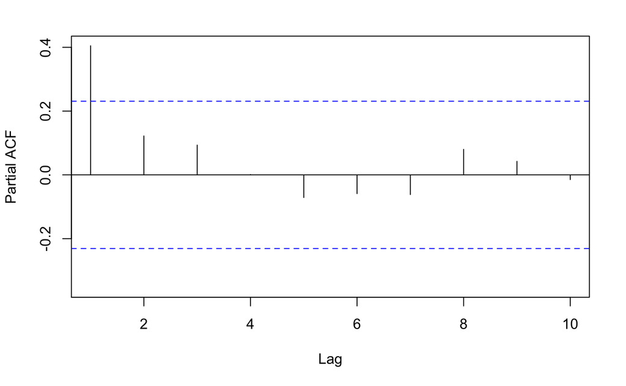

```r
Pacf(Model_A$residuals, lag.max = 10, main = "")
```

```r
#Problem 4c
#Establish an AR(2) model for the residuals in (b)
AR_Model <- Arima(Model_A$residuals, order =c(2,0,0))
AR_Model
```

```
Series: Model_A$residuals
ARIMA(2,0,0) with non-zero mean

Coefficients:
         ar1     ar2      mean
      0.7462  0.1506  3852.208
s.e.  0.1567  0.1595  5378.209

sigma^2 = 18530099:  log likelihood = -703.85
AIC=1415.7   AICc=1416.3   BIC=1424.81
```

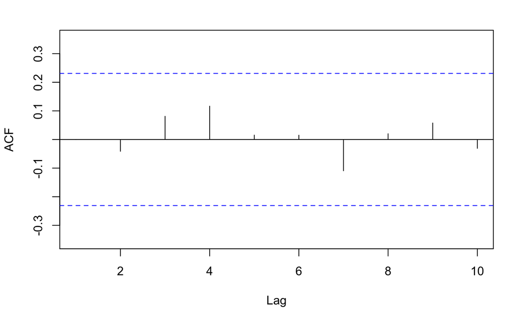

```r
#Problem 4d
#Plot ACF and PACF plot until lag 10 for residuals model for the AR(2) model
Acf(AR_Model$residuals, lag.max = 10, main = "")
```

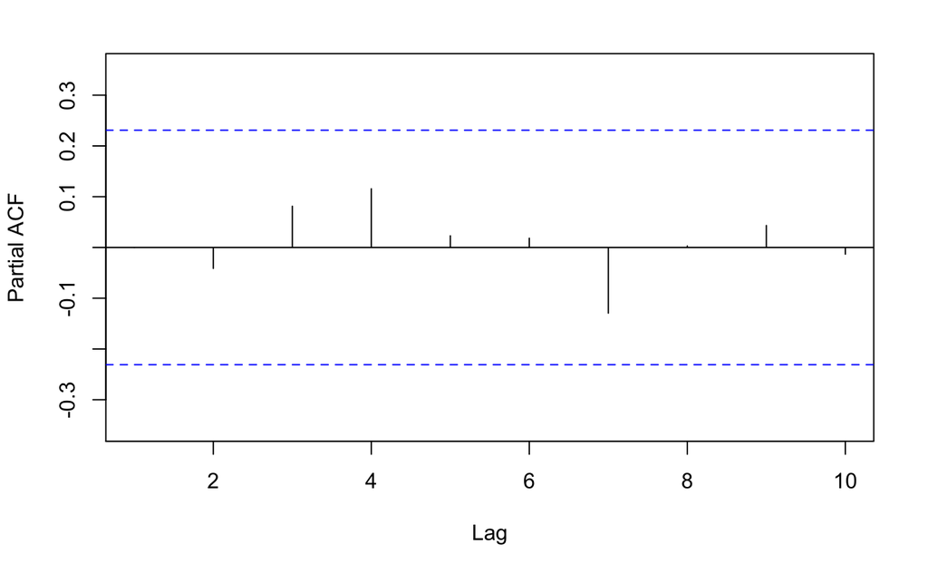

```r
Pacf(AR_Model$residuals, lag.max = 10, main = "")
```

```r
#Problem 4e
#Use auto.arima function to automatically find a best ARIMA model for the training period data
Model<-auto.arima(train.ts, seasonal=TRUE)
summary(Model)
```

```
Series: train.ts
ARIMA(0,1,2)(0,1,1)[12]

Coefficients:
          ma1     ma2    sma1
      -0.7050  0.4720  0.6439
s.e.   0.1416  0.1617  0.2139

sigma^2 = 13525127:  log likelihood = -570.12
AIC=1148.23   AICc=1148.97   BIC=1156.54

Training set error measures:
                  ME     RMSE      MAE       MPE     MAPE      MASE       ACF1
Training set 399.974 3243.385 2008.664 -2.008424 17.35956 0.5363874 0.05196872
```

```r
#Problem 4f
#Fit the identified model in (e) and plot the fitted values of the model and the observed training period data.
fit4 <- Arima(train.ts, order=c(0,1,2), seasonal=c(0,1,1))
summary(fit4)
```

```
Series: train.ts
ARIMA(0,1,2)(0,1,1)[12]

Coefficients:
          ma1     ma2    sma1
      -0.7050  0.4720  0.6439
s.e.   0.1416  0.1617  0.2139

sigma^2 = 13525127:  log likelihood = -570.12
AIC=1148.23   AICc=1148.97   BIC=1156.54

Training set error measures:
                  ME     RMSE      MAE       MPE     MAPE      MASE       ACF1
Training set 399.974 3243.385 2008.664 -2.008424 17.35956 0.5363874 0.05196872
```

```r
plot(train.ts, ylim = c(1500, 105000),  ylab = "Fitted",
     xlab = "Time", bty = "l", xaxt = "n", xlim = c(1995,2001.25), main = "Plot Fitted model and Observed Training Period")
axis(1, at = seq(1995, 2001, 1), labels = format(seq(1995, 2001, 1)))
```

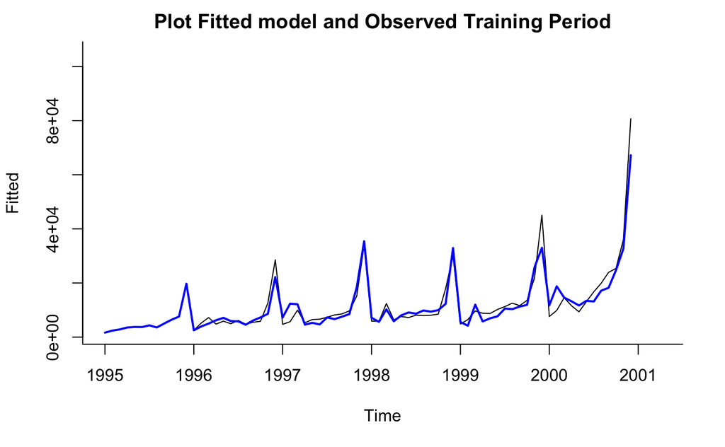

```r
lines(fit4$fitted, lwd = 2, col = "blue")
```

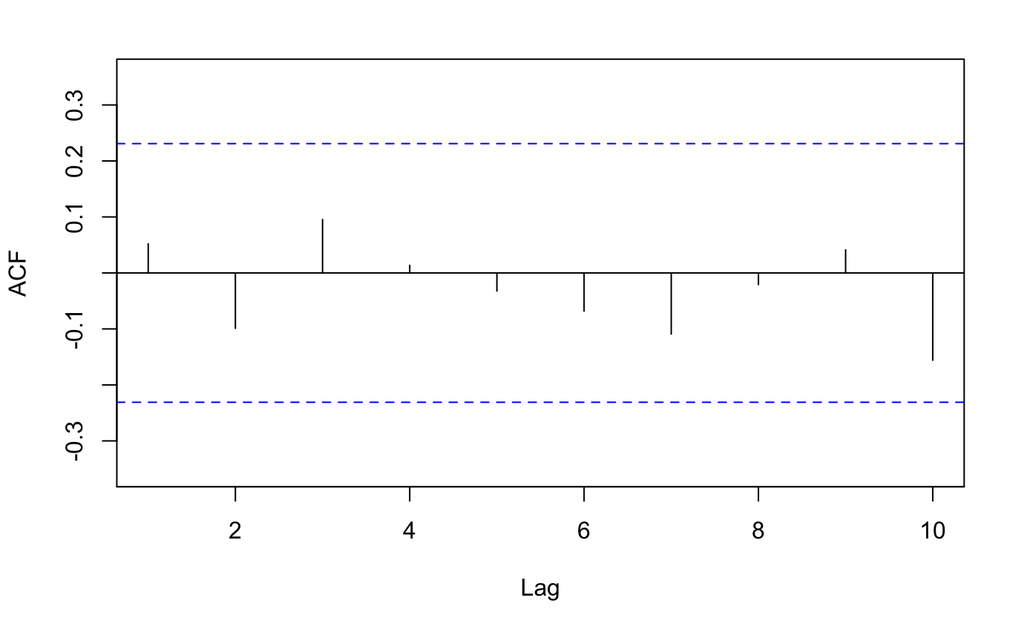

```r
#Problem 4g
#Create an ACF and PACF plot  until lag-10 for the residuals of model in (f)
Acf(fit4$residuals, lag.max = 10, main = "")
```

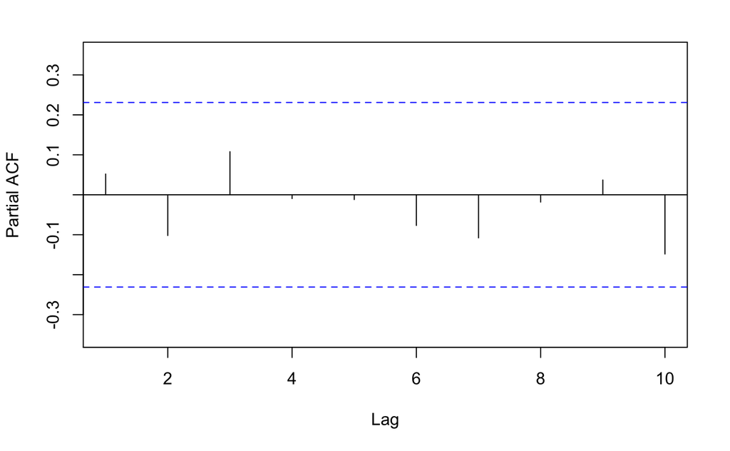

```r
Pacf(fit4$residuals, lag.max = 10, main = "")
```

```r
#Problem 4h
#Using the model in (a) to forecast for the validation period and obtain the forecasting accuracy
fc = forecast(Model_A , h = 12)
accuracy(fc, valid.ts)
```

```
                        ME      RMSE       MAE       MPE     MAPE     MASE      ACF1
Training set -5.684342e-14  5365.199  3205.089  6.967778 36.75088 0.855877 0.4048039
Test set      8.251513e+03 17451.547 10055.276 10.533974 26.66568 2.685130 0.3206228
             Theil's U
Training set        NA
Test set     0.9075924
```

```r
#Problem 4i
#Combining the model in (a) and (c) to forecast for the validation period and obtain the forecasting accuracy
fc.arima.resid = forecast(AR_Model, h = 12) #model c
#Combining the models for the final prediction
#The fc was used because that was the forecast done using model in a
final.pred <- fc$mean + fc.arima.resid$mean ## note: this is sum of level 1 and level 2 (resid.) prediction
accuracy(final.pred, valid.ts)
```

```
                ME     RMSE      MAE       MPE     MAPE      ACF1 Theil's U
Test set -10587.37 21770.25 18380.96 -90.58608 98.93337 0.4344632  2.447273
```

```r
#Problem 4j
#Using the model in (f) to forecast for the validation period and obtain the forecasting accuracy
fc.arima = forecast(fit4, h = 12)
accuracy(fc.arima, valid.ts)
```

```
                     ME      RMSE       MAE        MPE     MAPE      MASE       ACF1
Training set    399.974  3243.385  2008.664  -2.008424 17.35956 0.5363874 0.05196872
Test set     -18364.030 18579.263 18364.030 -88.847596 88.84760 4.9038739 0.09059368
             Theil's U
Training set        NA
Test set      2.157673
```

##Problem 4e

The model is ARIMA(0,1,2)(0,1,1)[12]

Note: The 12 is m . I just had to write it this way because there is no way to put it as a subscript in R.